# Part II - (Loan Data Exploration)

## by (Ethel Elikem)

## Investigation Overview

> In this investigation, I wanted to look at the features of a loan that could be used to predict its final status. The main focus was on the borrower rate, loan amountemployment status.

## Dataset Overview

> This data set contains 113,937 loans from 2005 to 2014 with 81 variables on each loan, including loan amount, borrower rate (or interest rate), current loan status, borrower income, and many others.

## Categories of Loan Status

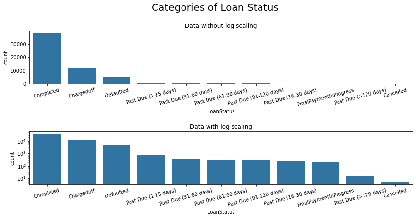

## Loan Status vs Employment status

> Majority of the loans with `completed` status have borrowers with employment status of `employed` or `full-time`. This form more than half of the dataset.

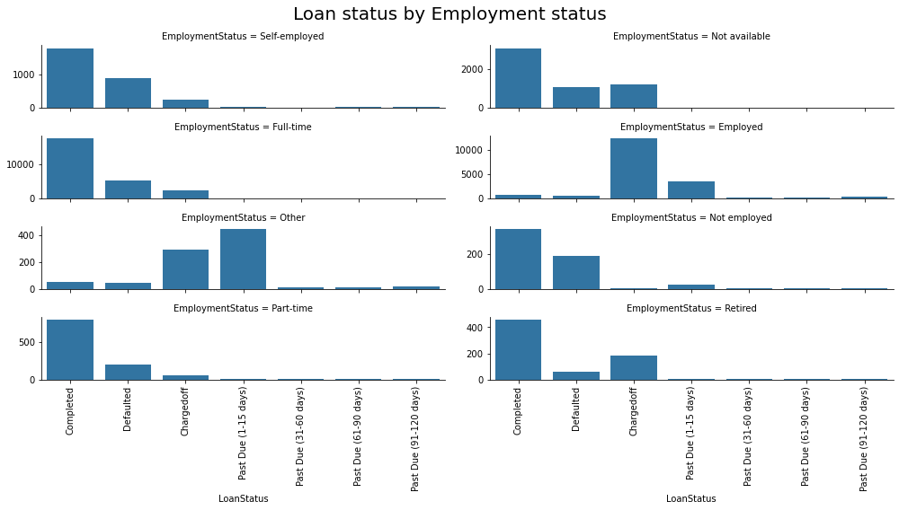

## Loan Status vs Loan Amount and Term

> Most loans irrespective of amount and status have a term of $36$ months or $60$ months.

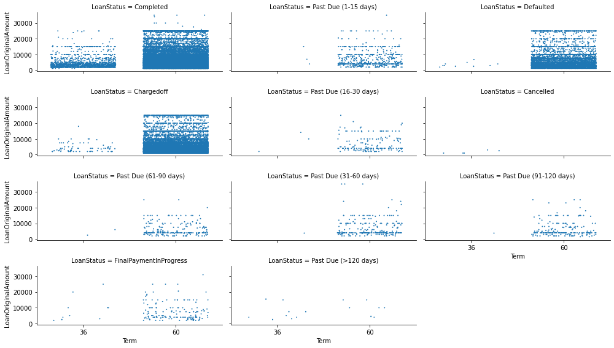

## Loan Status vs Loan Amount and Borrower Rate

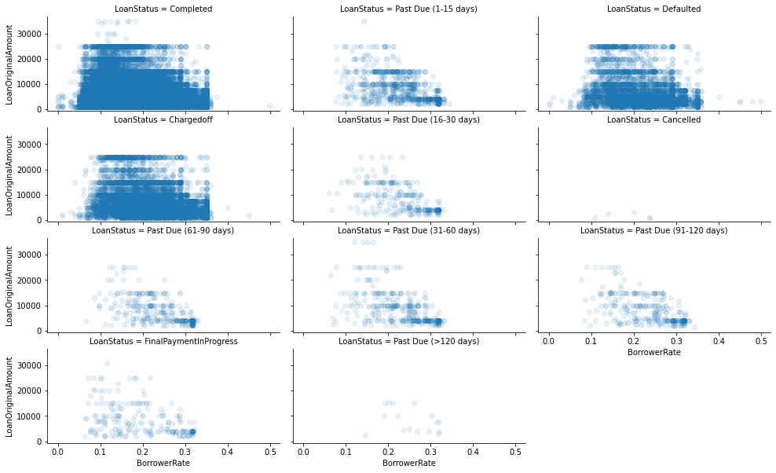